# Network Visualization

### Objectives

The objective of this module is to provide an overview to utilizing network analysis to visualize and analyze interaction, connected, or similarity data. Specifically, we present 1. Tools to modify a data matrix to generate network diagrams, 2. Applying various aesthetics to visNetwork diagrams, and 3. Generate Wilcoxon Test statistics make comparisons across groups.

### Preliminaries

```r
library(readr) # to enable tidying of data
library(dplyr) #""
library(tibble) #""
library(stats) #""
library(reshape2) # to use with melt function to convert matrix to objects igraph can plot
library(igraph) # to make an igraph object ie. network visualization of matrix values
library(visNetwork) # to make your igraph object prettier using visNetwork
library(bbe2020) # adds functionality to melt by converting a matrix generated in other software or elsewhere and converting to a form easily used by igraph
```

### Introduce dataset

A group of snakes were exposed to the presence of two “simulated” predators (i.e. two treatments), one with a simulated potential aerial “attack” (represented by a black t-shirt) and another with a simulated tactile “attack” (represented by a snake hook touch). A matrix was generated using Pearson correlation coefficient to calculate the behavior similarity indices between all snake’s antipredator head movement behavior.

```r
knitr::opts_chunk$set(echo = TRUE)
# read in data matrix for aerial treatment
aerial <- read_csv("blacktreatments_heads2020f.csv", col_names=TRUE)
# store the first column, which should be "names" for later use
aerialnames <- as.character(aerial$names)
# read in data matrix for tactile treatment
tactile <- read_csv("tactiletreatments_heads2020f.csv", col_names=TRUE)
# store the first column, which should be "names" for later use
tactilenames <- as.character(tactile$names)
## Please Note: you must ensure that your dataframe has a first column named "names" that refers to the labels for the unique row and column data points
```

### Using the Matrices, develop specific questions:

How similar did individual snakes move their heads in response to an aerial “attack”? How similar did individual snakes move their heads in response to a tactile “attack”? How does snake centrality of similarity compare between the aerial and tactile treatments?

### Background

Networks are made up of two essential components, ‘nodes’ (represented by symbols) and ‘edges’ (represented by lines between the nodes). These lines typically indicate an interaction between the nodes. Usually, in the context of social networks, the nodes are individuals and the edges are some measured interaction (Croft, James & Krause, 2008). Social network visualizations are called sociograms and illustrate a graphical representation of the data (presented as nodes and edges). Network visualizations can be used to visualize many forms of interaction profile similarity or adjacency matrices in biological systems (Bass et al. 2013).

### Tidying Data Matrix for iGraph Network analysis using bbe2020

```r
# melt_matrix_4_ig_visV <- function(x){
#   colnames(x) <- c("names", 1:nrow(x))
#   x <- select(x, -names) %>%
#   as.matrix()
#   x[lower.tri(x, diag=TRUE)] <- NA
#   x <- melt(x)
#   x <- setNames(x, c('ind1', 'ind2', 'values'))
#   x <- filter(x, !is.na(values))
#   return(x)
# }
#meltaerial <- melt_matrix_4_ig_visV(aerial)
# melting data matrix for aerial treatment
#melttactile <- melt_matrix_4_ig_visV(tactile)
```

```r
#Using "melteme" function, designed to melt the matrices
meltaerial <- meltme(aerial)
head(meltaerial, 5)
```

```
##   ind1 ind2     values
## 1    1    2 0.11953849
## 2    1    3 0.04906117
## 3    2    3 0.16703291
## 4    1    4 0.16615359
## 5    2    4 0.28997437
```

```r
# melting data matirx for tactile treatment
melttactile <- meltme(tactile)
#melttactile <- melt_matrix_4_ig_visV(tactile)
head(melttactile, 5)
```

```
##   ind1 ind2     values
## 1    1    2 0.04247999
## 2    1    3 0.15767443
## 3    2    3 0.11431884
## 4    1    4 0.21676272
## 5    2    4 0.12459046
```

### Data Visualization

Here we specifically visualize an individual snake’s antipredator behavior divided by all individual’s antipredator behavior towards the same type of predator represented as a ratio (or similarity index) in a sociogram. Each sociogram visualizes the similarity of antipredator behavior for either predator among the snakes. Edges represent the similarity index.

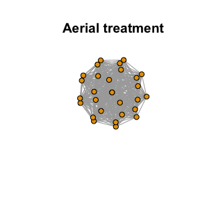

```r
# iGraph network plot of aerial treatment
#aerialplot <- graph_from_data_frame(meltaerial, directed = FALSE, vertices = NULL)
aerialplot <- igraphme(meltaerial)
E(aerialplot)$weight <- meltaerial$values
# print iGraph using a sphere layout
plot(aerialplot, vertex.label = NA, layout = layout_on_sphere, main="Aerial treatment")
```

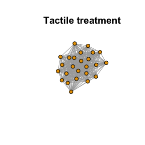

```r
# iGraph network plot of tactile treatment
#tactileplot <- graph_from_data_frame(melttactile, directed = FALSE, vertices = NULL)
tactileplot <- igraphme(melttactile)
E(tactileplot)$weight <- melttactile$values
# print iGraph using a force-directed layout (positions the nodes so that the edges have similar lengths and there are as few crossing edges as possible)
plot(tactileplot, vertex.label = NA, layout = layout_with_fr, main="Tactile treatment")
```

```r
# converting igraph to visnetwork for aerial treatment
aerialdata <- toVisNetworkData(aerialplot)
## copy column "weight" to new column "value" in list "edges"
aerialdata$edges$width <- 20*aerialdata$edges$value
## line color
aerialdata$edges$color <- "gray"
## node labels
##refer to "aerialnames" to do this
aerialdata$nodes$label <- aerialnames
## print plot, zoom in for detail!
visNetwork(nodes = aerialdata$nodes, edges = aerialdata$edges, height = "500px") %>%
visIgraphLayout(layout = "layout_with_sugiyama")
```

[interactive chart not shown]

```r
# converting igraph to visnetwork for tactile treatment
tactiledata <- toVisNetworkData(tactileplot)
## copy column "weight" to new column "value" in list "edges"
tactiledata$edges$width <- 20*tactiledata$edges$value
## line color
tactiledata$edges$color <- "gray"
## print plot
visNetwork(nodes = tactiledata$nodes, edges = tactiledata$edges, height = "500px") %>%
visIgraphLayout(layout = "layout_with_sugiyama")
```

[interactive chart not shown]

### Calculate eigenvalue centrality of aerial and tactile treatments.

```r
# aerial treatment
centralityaerialplot <- evcent(aerialplot)$vector
centralityaerialplot
```

```
##           1           2           3           4           5           6
## 0.070625411 0.092009815 0.721700092 0.072710846 0.903852136 0.062483150
##           7           8           9          10          11          12
## 0.858183875 0.422838104 0.422714502 0.869743842 0.887871413 0.073218872
##          13          14          15          16          17          18
## 1.000000000 0.999651390 0.999706871 0.080420819 0.065086751 0.092009815
##          19          20          21          22          23          24
## 0.420466444 0.000000000 0.999829213 0.417071377 0.769400758 0.887871413
##          25          26          27          28          29
## 0.073218872 0.887871413 0.092009815 0.887871413 0.007328925
```

```r
# tactile treatment
centralitytactileplot <- evcent(tactileplot)$vector
centralitytactileplot
```

```
##         1         2         3         4         5         6         7         8
## 0.5829309 0.6922794 1.0000000 0.7148322 0.8860956 0.6600421 0.6893604 0.8175895
##         9        10        11        12        13        14        15        16
## 0.5171066 0.7403537 0.4310905 0.7495318 0.6673493 0.6910545 0.8612071 0.7973011
##        17        18        19        20        21        22        23        24
## 0.8993683 0.7795117 0.5483421 0.8657628 0.7572662 0.8663443 0.8384841 0.6231616
##        25
## 0.9221214
```

### Calculate centrality of similarity index between an aerial and tactile treatments.

To determine if there is any significant difference between the predator responses of our snakes towards the two artificially simulated predators (aerial and tactile) we compared the snakes scores of centrality (connectedness). Centrality is a network statistic which is a measure of being well-connected.

```r
# First, we need to combine our centrality measures for both the aerial and tactical treatment conditions into one dataframe
# names and centraility score for aerial treatment condition
Acent <- bind_cols(name = aerialnames, number = centralityaerialplot)
# names and centriality score for tactile treatment condition
Tcent <- bind_cols(name = tactilenames, number = centralitytactileplot)
# naming the different centrality measures for each treatment condition
acondition = 'aerial'
tcondition = 'tactile'
Acent <- mutate(Acent, "condition" = paste(acondition))
Acent
```

```
## # A tibble: 29 x 3
##    name                           number condition
##    <chr>                           <dbl> <chr>
##  1 Oxyrhopus_melanogenys_RAB581_  0.0706 aerial
##  2 Oxyrhopus_melanogenys_RAB584_  0.0920 aerial
##  3 Oxyrhopus_melanogenys_RAB607_  0.722  aerial
##  4 Oxyrhopus_petolarius_RAB667_   0.0727 aerial
##  5 Oxyrhopus_petolarius_RAB664_   0.904  aerial
##  6 Oxyrhopus_petolarius_RAB672_   0.0625 aerial
##  7 Oxyrhopus_petolarius_RAB697_   0.858  aerial
##  8 Oxyrhopus_melanogenys_RAB936_  0.423  aerial
##  9 Oxyrhopus_melanogenys_RAB1005_ 0.423  aerial
## 10 Oxyrhopus_melanogenys_RAB938_  0.870  aerial
## # … with 19 more rows
```

```r
Tcent <- mutate(Tcent, "condition" = paste(tcondition))
Tcent
```

```
## # A tibble: 25 x 3
##    name                           number condition
##    <chr>                           <dbl> <chr>
##  1 Oxyrhopus_melanogenys_RAB584_   0.583 tactile
##  2 Oxyrhopus_petolarius_RAB664_    0.692 tactile
##  3 Oxyrhopus_petolarius_RAB672_    1     tactile
##  4 Oxyrhopus_petolarius_RAB697_    0.715 tactile
##  5 Oxyrhopus_melanogenys_RAB936_   0.886 tactile
##  6 Oxyrhopus_melanogenys_RAB1005_  0.660 tactile
##  7 Oxyrhopus_melanogenys_RAB938_   0.689 tactile
##  8 Oxyrhopus_melanogenys_RAB1004_  0.818 tactile
##  9 Oxyrhopus_melanogenys_RAB955_   0.517 tactile
## 10 Oxyrhopus_melanogenys_RAB1233_  0.740 tactile
## # … with 15 more rows
```

```r
# Joining aerial and tactile treatments with their centralities and snakenames into one tibble
snake_centrality <- full_join(Tcent, Acent, by = "name")
snake_centrality
```

```
## # A tibble: 30 x 5
##    name                           number.x condition.x number.y condition.y
##    <chr>                             <dbl> <chr>          <dbl> <chr>
##  1 Oxyrhopus_melanogenys_RAB584_     0.583 tactile       0.0920 aerial
##  2 Oxyrhopus_petolarius_RAB664_      0.692 tactile       0.904  aerial
##  3 Oxyrhopus_petolarius_RAB672_      1     tactile       0.0625 aerial
##  4 Oxyrhopus_petolarius_RAB697_      0.715 tactile       0.858  aerial
##  5 Oxyrhopus_melanogenys_RAB936_     0.886 tactile       0.423  aerial
##  6 Oxyrhopus_melanogenys_RAB1005_    0.660 tactile       0.423  aerial
##  7 Oxyrhopus_melanogenys_RAB938_     0.689 tactile       0.870  aerial
##  8 Oxyrhopus_melanogenys_RAB1004_    0.818 tactile       0.888  aerial
##  9 Oxyrhopus_melanogenys_RAB955_     0.517 tactile       0.0732 aerial
## 10 Oxyrhopus_melanogenys_RAB1233_    0.740 tactile       1      aerial
## # … with 20 more rows
```

```r
snake_centrality <- as.data.frame(snake_centrality)
head(snake_centrality, 5)
```

```
##                            name  number.x condition.x   number.y condition.y
## 1 Oxyrhopus_melanogenys_RAB584_ 0.5829309     tactile 0.09200982      aerial
## 2  Oxyrhopus_petolarius_RAB664_ 0.6922794     tactile 0.90385214      aerial
## 3  Oxyrhopus_petolarius_RAB672_ 1.0000000     tactile 0.06248315      aerial
## 4  Oxyrhopus_petolarius_RAB697_ 0.7148322     tactile 0.85818387      aerial
## 5 Oxyrhopus_melanogenys_RAB936_ 0.8860956     tactile 0.42283810      aerial
```

```r
## Re-naming the columns after cmbining the columns
snake_centrality <- snake_centrality %>%
  rename(
    centrality_t = number.x,
    centrality_a = number.y
  )
head(snake_centrality, 5)
```

```
##                            name centrality_t condition.x centrality_a
## 1 Oxyrhopus_melanogenys_RAB584_    0.5829309     tactile   0.09200982
## 2  Oxyrhopus_petolarius_RAB664_    0.6922794     tactile   0.90385214
## 3  Oxyrhopus_petolarius_RAB672_    1.0000000     tactile   0.06248315
## 4  Oxyrhopus_petolarius_RAB697_    0.7148322     tactile   0.85818387
## 5 Oxyrhopus_melanogenys_RAB936_    0.8860956     tactile   0.42283810
##   condition.y
## 1      aerial
## 2      aerial
## 3      aerial
## 4      aerial
## 5      aerial
```

```r
## running the wilcoxon analysis on our updated dataframe to compare snake centrality in the tactile and aerial treatment conditions
wilcox_centrality <- wilcox.test(snake_centrality$centrality_t, snake_centrality$centrality_a, paired=TRUE)
wilcox_centrality
```

```
##
##  Wilcoxon signed rank exact test
##
## data:  snake_centrality$centrality_t and snake_centrality$centrality_a
## V = 223, p-value = 0.03665
## alternative hypothesis: true location shift is not equal to 0
```

### Another Example Using Association to Demonstrate Aesthetic Changes

In this new example, we showcase a selection of different aesthetic changes you can utilize in your visualization of network data based on monkey association patterns.

```r
# Read in another dataset, here we use monkeys
Monkeys <- read_csv("EM_monkey.csv", col_names=TRUE)
Sname <- c(Monkeys$name)
Sno <- as.numeric(1:nrow(Monkeys))
Monkeys <- meltme(Monkeys)
#Monkeys <- melt_matrix_4_ig_visV(Monkeys)
head(Monkeys, 5)
```

```
##   ind1 ind2     values
## 1    1    2 0.00000000
## 2    1    3 0.09285714
## 3    2    3 0.02857143
## 4    1    4 0.02142857
## 5    2    4 0.00000000
```

```r
# This is how you can replace numbers with names
Source <- bind_cols(name = Sname, number = Sno)
Source
```

```
## # A tibble: 11 x 2
##    name     number
##    <chr>     <dbl>
##  1 Anita         1
##  2 Carlos        2
##  3 Chico         3
##  4 Junon         4
##  5 Kato          5
##  6 Manuel        6
##  7 Penelope      7
##  8 Popeye        8
##  9 Reuben        9
## 10 Rosa         10
## 11 Sol          11
```

```r
final <- inner_join(Monkeys, Source, by = c("ind1" = "number"))
final <- inner_join(final, Source, by = c("ind2" = "number"))
final <- select(final, name.x, name.y, values)
head(final, 5)
```

```
##   name.x name.y     values
## 1  Anita Carlos 0.00000000
## 2  Anita  Chico 0.09285714
## 3 Carlos  Chico 0.02857143
## 4  Anita  Junon 0.02142857
## 5 Carlos  Junon 0.00000000
```

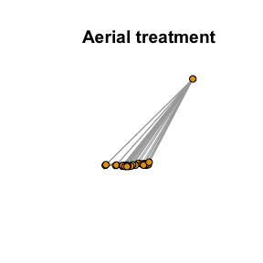

```r
# Visualization of Monkey interactions
Monkeysp <- graph_from_data_frame(Monkeys, directed = FALSE, vertices = NULL)
plot(aerialplot, vertex.label = NA, layout = layout_with_fr, main="Aerial treatment")
```

```r
datam <- toVisNetworkData(Monkeysp)
visNetwork(nodes = datam$nodes, edges = datam$edges, height = "500px") %>%
visIgraphLayout(layout = "layout_with_sugiyama")
```

[interactive chart not shown]

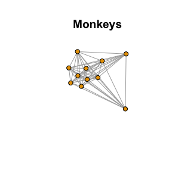

```r
# New monkey graph to work out the centrality of monkeys.
# igraph
monk = graph.data.frame(final[,c('name.x','name.y')], directed = FALSE, vertices = NULL)
E(monk)$weight = final$values
plot(monk, vertex.label = NA, layout = layout_with_fr, main="Monkeys")
```

```r
# working out centrality
centrality <- evcent(monk)$vector
head(centrality)
```

```
##      Anita     Carlos      Chico      Junon       Kato     Manuel
## 1.00000000 0.04882458 0.59551423 0.25984965 0.03560658 0.21484381
```

### Inferring Results

With respect to the antipredator behavior of snake head displays, individual snakes typically behaved significantly different between aerial and tactile treatments, as expected.

### Concept Overview

- Networks are made up of two essential components, ‘nodes’ (represented by symbols) and ‘edges’ (represented by lines between the nodes). These lines typically indicate an interaction between the nodes
- Using the {bbe2020()} to:
  - `meltme()` function to convert matrix data into a dataframe for igraph manipulation
  - `igraphme()` function to convert a melted matrix into an igraph format for network visualization & analysis
- Using {igraph}: graph_from_data_frame() and {visNetwork}: toVisNetworkData() to generate sociograms
- Aesthetic changes in visNetwork sociograms, such as `edge$color` , `edge$width`
- Eigenvector centrality statistics in igraph evcent()$vector
- The `wilcox.test()` function is a non-parametric statistical test which compares two paired groups